# (해양) 해수면온도 활용 가이던스

## 1. 데이터셋 개요

- **기간**: 2015 - 2023 (월간)
- **해상도**: 0.05° (약 5km)
- **포맷**: NetCDF-4 (HDF5) / Zarr

### 주요 자료 설명

| 자료 종류 | 파일명 (예시) | 주요 변수명 | 관측 주기 |
| --- | --- | --- | --- |
| **월평균** | `L3_CDR_Monthly_201501_202312_Final_Combinded_gapfilled.nc` | `SST_L3_monthly`, `observation_count` | 월간 |

### 관련 참조 문서

- **PUG (자료의 정의)**: NMSC 해수면 온도 데이터 포맷 및 구조 설명
- **ATBD (산출방법)**: 알고리즘 및 물리적 산출 과정
- **Validation Report (검증결과)**: 현장 관측 자료(부이 등)와의 정확도 검증 결과

### 용어 사전

이 가이드를 읽기 전, 아래에 사용된 주요 약어와 기상/위성 용어를 참고하시기 바랍니다.

- **NMSC (National Meteorological Satellite Center)**: 국가기상위성센터
- **SST (Sea Surface Temperature)**: 해수면온도
- **ECV (Essential Climate Variable)**: 핵심기후변수
- **CDR (Climate Data Record)**: 과거부터 장기간에 걸쳐 일관성 있게 생산된 기후자료 기록
- **Climatology (기후 평년값)**: 특정 기간(보통 30년, 예: 1991~2020) 동안의 기상 요소 평균 상태
- **Anomaly (편차)**: 특정 시점의 관측값이 평년값에서 벗어난 정도

```python
import xarray as xr
import matplotlib.pyplot as plt
import pandas as pd
from IPython.display import display, HTML

from nmsc_climate_toolbox import NMSCClimateToolbox

nct = NMSCClimateToolbox()
```

## 2. 데이터 읽기

```python
# 사용자 환경에 맞게 분석할 파일 경로를 설정해 주세요.
# 예: 월평균 데이터를 사용하여 시계열/공간 분석을 수행합니다.
file_path = 'doc/L3_CDR_Monthly_201501_202312_Final_Combinded_gapfilled.nc'
ds = nct.open(file_path)
var_name = 'SST_L3_monthly'
print(ds)
```

[output not shown]

## 3. 시공간 필터

```python
ds_filtered = nct.filter(ds, time_slice=slice('2015-01-01', '2020-12-31'))
print(f"필터링 후 시간 범위: {ds_filtered.time.min().values} ~ {ds_filtered.time.max().values}")
```

```
필터링 후 시간 범위: 2015-01-01T00:00:00.000000000 ~ 2020-12-01T00:00:00.000000000
```

## 4. 기후 평년값 및 편차 산출

```python
ds_resampled, ds_cli, ds_ano = nct.process_climate_data(
    dataset=ds,
    freq='1MS',  # 월간 산출
    op='평균',
    start_yr='2015-01-01',
    end_yr='2020-12-31'
)
print("기후 평년값:", ds_cli)
print("편차:", ds_ano)
```

```
기후 평년값: <xarray.Dataset> Size: 121MB
Dimensions:               (month: 12, lat: 700, lon: 900)
Coordinates:
  * month                 (month) int64 96B 1 2 3 4 5 6 7 8 9 10 11 12
  * lat                   (lat) float64 6kB 15.0 15.05 15.1 ... 49.85 49.9 49.95
  * lon                   (lon) float64 7kB 105.0 105.0 105.1 ... 149.9 149.9
Data variables:
    SST_L3_monthly        (month, lat, lon) float32 30MB dask.array<chunksize=(1, 468, 600), meta=np.ndarray>
    analysis_uncertainty  (month, lat, lon) float32 30MB dask.array<chunksize=(1, 468, 600), meta=np.ndarray>
    observation_count     (month, lat, lon) float64 60MB dask.array<chunksize=(1, 468, 600), meta=np.ndarray>
Attributes: (12/22)
    title:                Monthly CDR merged from COMS and GK2A
    institution:          Created by merge_monthly_cdr.py
    source:               COMS L3 Monthly (2015-2019) + GK2A L3 Monthly (2020...
    processing_level:     L3
    product_version:      V3_final_v2
    Conventions:          CF-1.8, ACDD-1.3
    ...                   ...
    interpolation_note:   SST uses bilinear for smooth temperature field; std...
    n_input_files:        742
    coverage_percent:     97.76362407031777
    year_month:           2015-01
    satellite:            COMS
    history:              Merged on 2025-12-01T04:52:11\n2025-12-08 12:04:28:...
편차: <xarray.Dataset> Size: 1GB
Dimensions:               (lat: 700, lon: 900, time: 108)
Coordinates:
  * lat                   (lat) float64 6kB 15.0 15.05 15.1 ... 49.85 49.9 49.95
  * lon                   (lon) float64 7kB 105.0 105.0 105.1 ... 149.9 149.9
  * time                  (time) datetime64[ns] 864B 2015-01-01 ... 2023-12-01
    month                 (time) int64 864B 1 2 3 4 5 6 7 8 ... 6 7 8 9 10 11 12
Data variables:
    SST_L3_monthly        (time, lat, lon) float32 272MB dask.array<chunksize=(1, 468, 600), meta=np.ndarray>
    analysis_uncertainty  (time, lat, lon) float32 272MB dask.array<chunksize=(1, 468, 600), meta=np.ndarray>
    observation_count     (time, lat, lon) float64 544MB dask.array<chunksize=(1, 468, 600), meta=np.ndarray>
Attributes: (12/22)
    title:                Monthly CDR merged from COMS and GK2A
    institution:          Created by merge_monthly_cdr.py
    source:               COMS L3 Monthly (2015-2019) + GK2A L3 Monthly (2020...
    processing_level:     L3
    product_version:      V3_final_v2
    Conventions:          CF-1.8, ACDD-1.3
    ...                   ...
    interpolation_note:   SST uses bilinear for smooth temperature field; std...
    n_input_files:        742
    coverage_percent:     97.76362407031777
    year_month:           2015-01
    satellite:            COMS
    history:              Merged on 2025-12-01T04:52:11\n2025-12-08 12:04:28:...
```

## 5. 이미지 영상

선택된 변수의 특정 시간대 데이터를 이미지 영상으로 시각화합니다. `cmap_name`을 통해 색상표를 변경할 수 있습니다.

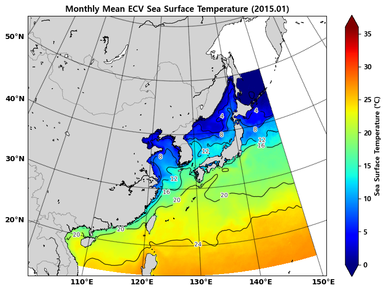

```python
nct.resMap(ds, variable=var_name, time_idx=0, cmap_name='jet', custom_title="Monthly Mean ECV Sea Surface Temperature (%Y.%m)", custom_legend="Sea Surface Temperature (°C)", return_type='fig')
plt.show()
```

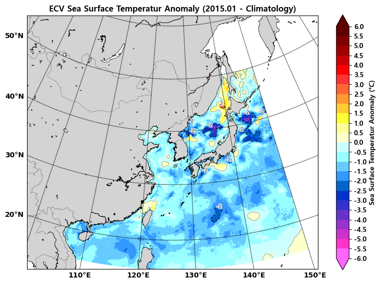

```python
# 편차 데이터 시각화
nct.resMap(
    dataset=ds,
    variable=var_name,
    time_idx=0,
    data_layer='anomaly',
    cmap_name='SST_ANOM (custom)',
    dataset_cli=ds_cli,
    custom_title="ECV Sea Surface Temperatur Anomaly (%Y.%m - Climatology)",
    custom_legend="Sea Surface Temperatur Anomaly (°C)",
    return_type='fig'
)
plt.show()
```

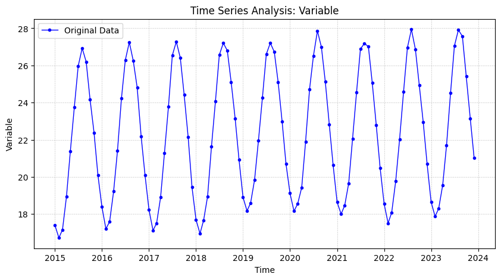

```python
var_name = 'SST_L3_monthly'
ts_mean_da = nct.spaMean(ds_resampled, variable=var_name)
fig_ts = nct.timeGrp(ts_mean_da)
plt.show()
```

## 7. 통계 시각화 및 극한 기후 분석

### 7.1. 데이터 분포 확인 (히스토그램)

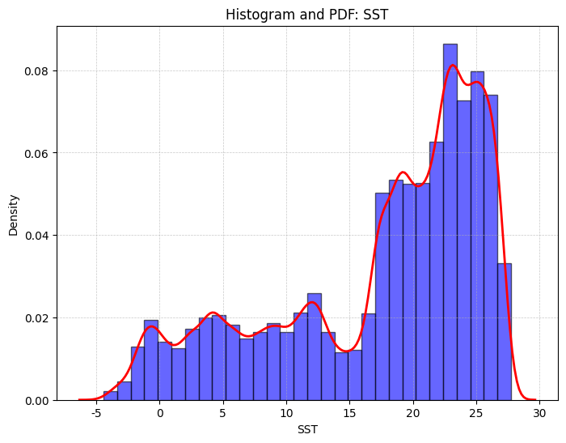

```python
data_at_time = ds[var_name].isel(time=0)
fig_hist = nct.histGrp(data_at_time, bins=30, variable_name="SST")
plt.show()
```

### 7.2. 연도별 통계량 비교 (막대 그래프)

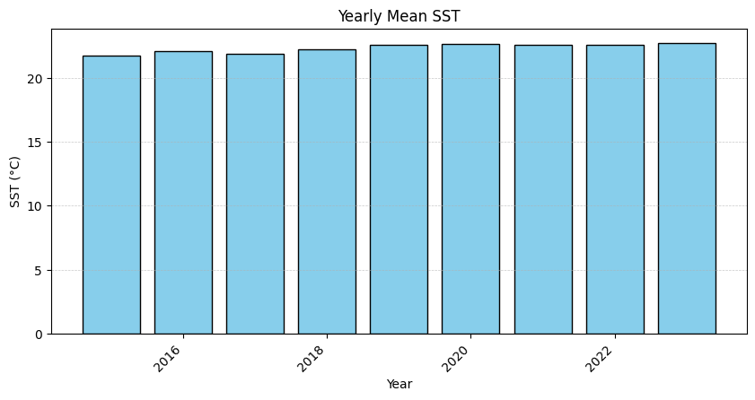

```python
yearly_mean = ts_mean_da.groupby('time.year').mean(dim='time')
years = yearly_mean['year'].values
values = yearly_mean.values
fig_bar = nct.barGrp(years, values, title="Yearly Mean SST", xlabel="Year", ylabel="SST (°C)")
plt.show()
```

### 7.3. 극한 기후 분석

```python
ext_results = nct.ext(ts_mean_da, percentile=0.95)
print("=== 극한 기후 분석 결과 ===")
print(f"95% 백분위수 임계값: {ext_results['threshold']:.3f}")
print(f"임계값 초과 발생 횟수: {ext_results['extreme_count']}회")
print(f"Sen's Slope (견고한 추세선): {ext_results['sens_slope']:.5f}")
```

```
=== 극한 기후 분석 결과 ===
95% 백분위수 임계값: 27.234
임계값 초과 발생 횟수: 6회
Sen's Slope (견고한 추세선): 0.01524
```